# Course Project 1

Esosa C. Orumwese

6/1/2021

## Introduction

It is now possible to collect a large amount of data about personal movement using activity monitoring devices such as a Fitbit, Nike

Fuelband, or Jawbone Up. These type of devices are part of the “quantified self” movement – a group of enthusiasts who take measurements

about themselves regularly to improve their health, to find patterns in their behavior, or because they are tech geeks. But these data

remain under-utilized both because the raw data are hard to obtain and there is a lack of statistical methods and software for processing

and interpreting the data.

This assignment makes use of data from a personal activity monitoring device. This device collects data at 5 minute intervals through out

the day. The data consists of two months of data from an anonymous individual collected during the months of October and November, 2012 and

include the number of steps taken in 5 minute intervals each day.

The data for this assignment can be downloaded from the course web site:

Dataset: [Activity monitoring data](https://d396qusza40orc.cloudfront.net/repdata%2Fdata%2Factivity.zip)

The variables included in this dataset are:

1. steps: Number of steps taking in a 5-minute interval (missing values are coded as NA)
2. date: The date on which the measurement was taken in YYYY-MM-DD format
3. interval: Identifier for the 5-minute interval in which measurement was taken

The dataset is stored in a comma-separated-value (CSV) file and there are a total of 17,568 observations in this dataset.

## Loading and Preprocessing Data

### Downloading and Unzipping data

```r
Url <- "https://d396qusza40orc.cloudfront.net/repdata%2Fdata%2Factivity.zip"
download.file(Url, destfile = paste(getwd(),"dataFiles.zip",sep = "/"))

##Unzipping the file
unzip(zipfile = "dataFiles.zip")
```

### Reading the csv data file

```r
activityDT <- read.csv("activity.csv", header = TRUE)
```

## What is the mean total number of steps taken per day?

### Calculate the number of steps taken per day

```r
library(dplyr)
Total.steps <- na.omit(activityDT) %>% group_by(date) %>% summarise(Total.steps = sum(steps))
head(Total.steps, 10)
```

```
## # A tibble: 10 x 2
##    date       Total.steps
##    <chr>            <int>
##  1 2012-10-02         126
##  2 2012-10-03       11352
##  3 2012-10-04       12116
##  4 2012-10-05       13294
##  5 2012-10-06       15420
##  6 2012-10-07       11015
##  7 2012-10-09       12811
##  8 2012-10-10        9900
##  9 2012-10-11       10304
## 10 2012-10-12       17382
```

### Histogram of the total number of steps taken per day

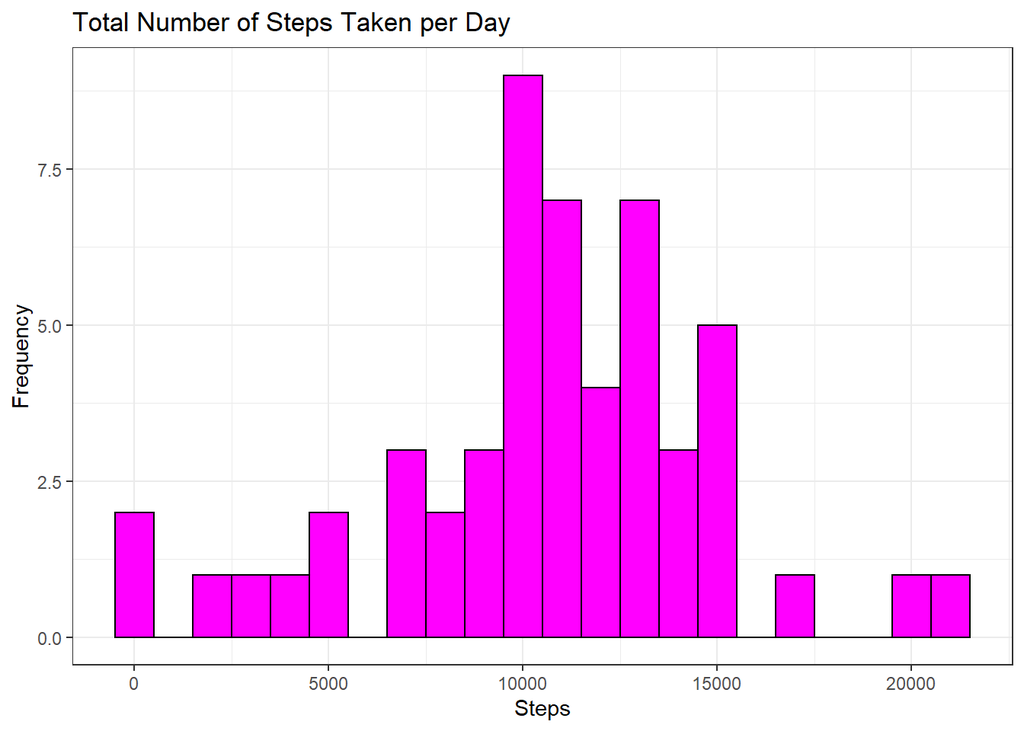

```r
library(ggplot2)

ggplot(Total.steps, aes(Total.steps)) + geom_histogram(fill = "magenta", binwidth = 1000, color="black") + theme_bw() +
        labs(x="Steps",y="Frequency",title="Total Number of Steps Taken per Day")
```

### Mean and Median of the Total number of steps taken per day

```r
median.total.steps <- median(Total.steps$Total.steps)
median.total.steps
```

```
## [1] 10765
```

```r
mean.total.steps <- mean(Total.steps$Total.steps)
mean.total.steps
```

```
## [1] 10766.19
```

- The mean of the total number of steps taken per day is stored in the variable *mean.total.steps*
- The median of the total number of steps taken per day is stored in the variable *median.total.steps*

## What is the average daily activity pattern?

### Make a time series plot (i.e. type = “l”) of the 5-minute interval (x-axis) and the average number of steps taken, averaged across all days (y-axis)

```r
steps.interval <- na.omit(activityDT) %>% group_by(interval) %>% summarise(Average.steps = mean(steps))
```

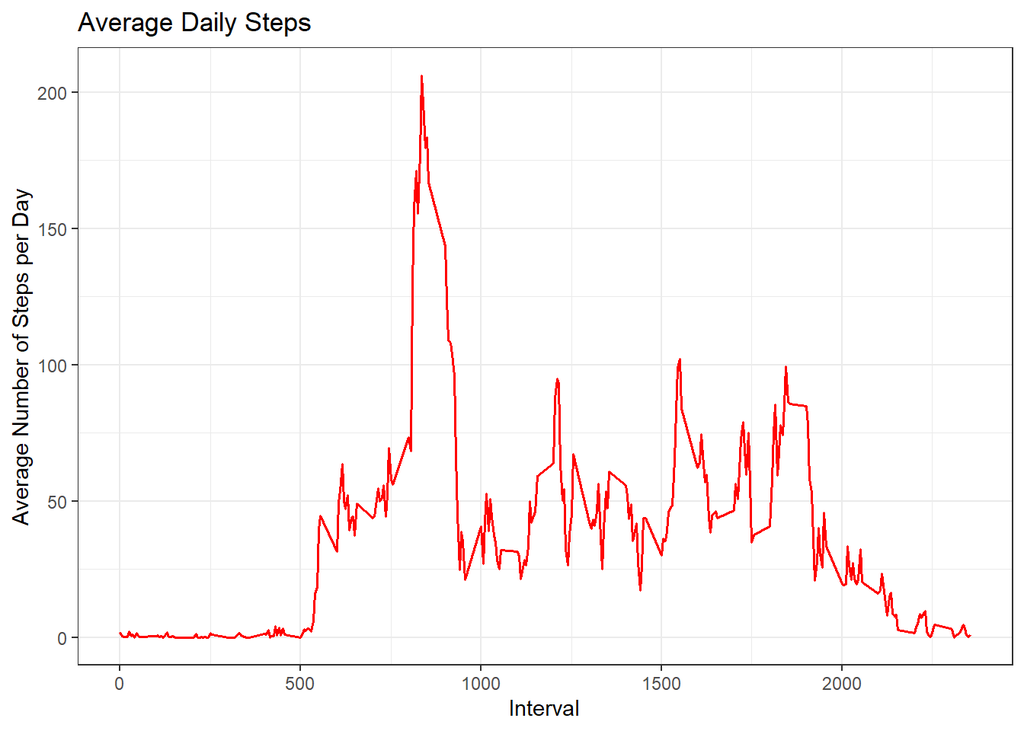

```r
ggplot(steps.interval, aes(x=interval,y=Average.steps)) + geom_line(color = "red", size = 0.6) + theme_bw() +
        labs(x="Interval",y="Average Number of Steps per Day",title="Average Daily Steps")
```

### Which 5-minute interval, on average across all the days in the dataset, contains the maximum number of steps?

```r
interval.Maxsteps <- steps.interval[which.max(steps.interval$Average.steps),1]
interval.Maxsteps
```

```
## # A tibble: 1 x 1
##   interval
##      <int>
## 1      835
```

- The 5-minute interval that contains the maximum number of steps is contained in the variable *interval.Maxcsteps*

## Imputing missing values

### Calculate and report the total number of missing values in the dataset

```r
numberof.NA <- sum(is.na(activityDT$steps))
numberof.NA
```

```
## [1] 2304
```

- The total number of missing values in the dataset is stored in the variable, *numberof.NA*

### Devise a strategy for filling in all of the missing values in the dataset. Missings values will be the average of that time interval

```r
getMeansteps.per.Interval <- function(interval){
        value <- steps.interval[steps.interval$interval==interval,]$Average.steps
        round(value,3)
}
```

### Create a new dataset that is equal to the original dataset but with the missing data filled in.

```r
activityDT.NAimput <- activityDT

for (i in 1:nrow(activityDT.NAimput)) {
        if (is.na(activityDT.NAimput$steps[i]) == TRUE) {
                interval.value <- activityDT.NAimput$interval[i]
                new.steps.value <- getMeansteps.per.Interval(interval.value)
                activityDT.NAimput$steps[i] <- new.steps.value
        } else {}
}
```

- The new dataset, which is similar to the original data set (*activityDT*), is stored in *activityDT.NAimput*

### Make a histogram of the total number of steps taken each day and Calculate and report the mean and median total number of steps taken per day. Do these values differ from the estimates from the first part of the assignment? What is the impact of imputing missing data on the estimates of the total daily number of steps?

Questions

1. Histogram of the total number of steps taken each day
2. Calculate and report the mean and median total number of steps taken per day.
3. Do these value differ from the estimates from the first part of the assignment?
4. What is the impact of imputing missing data on the estimates of the total daily number of steps?

#### Histogram of the total number of steps taken each day.

```r
Total.steps.NAimput <- activityDT.NAimput %>% group_by(date) %>% summarise(steps = sum(steps))
```

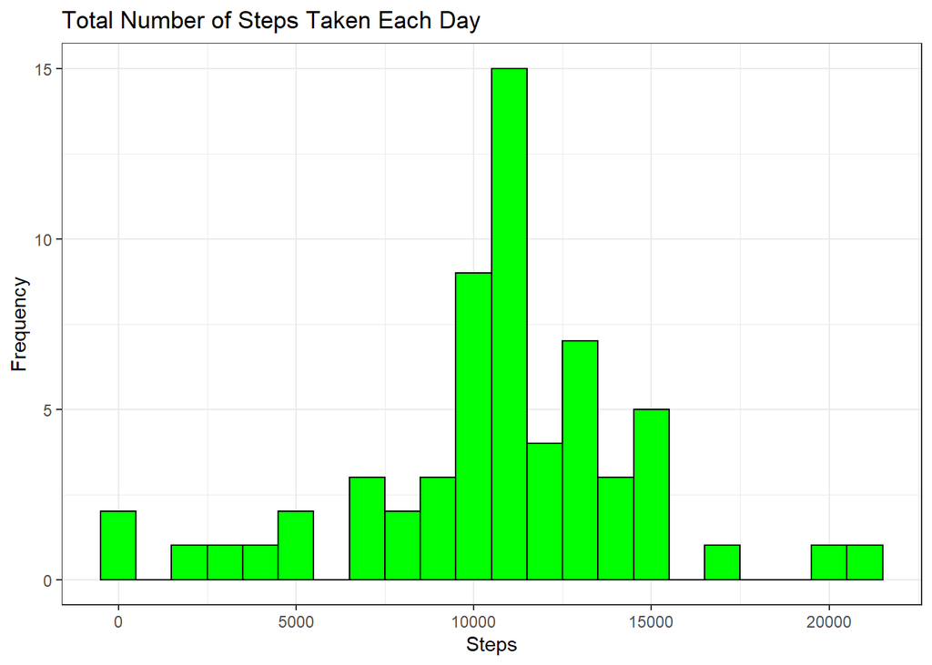

```r
ggplot(Total.steps.NAimput, aes(steps)) + theme_bw() +
        geom_histogram(fill = "green",color = "black", binwidth = 1000) +
        labs(x="Steps", y="Frequency", title = "Total Number of Steps Taken Each Day")
```

#### Calculate and report the mean and median total number of steps taken per day.

```r
mean.total.steps.NAimput <- mean(Total.steps.NAimput$steps)
mean.total.steps.NAimput
```

```
## [1] 10766.19
```

```r
median.total.steps.NAimput <- median(Total.steps.NAimput$steps)
median.total.steps.NAimput
```

```
## [1] 10766.19
```

- The mean total number of steps taken per day is stored in the variable, *mean.total.steps.NAimput*
- The median total number of steps taken per dat is stored in the variable, *median.total.steps.NAimput*

#### Do these value differ from the estimates from the first part of the assignment?

- The mean values remained the same, while the median values showed a percentage difference of 0.01%

#### What is the impact of imputing missing data on the estimates of the total daily number of steps?

```r
estimate <- sum(Total.steps$Total.steps)
imput <- sum(Total.steps.NAimput$steps)
percent.increase <- ((imput - estimate)/estimate)*100
paste(round(percent.increase,2),"%",sep = "")
```

```
## [1] "15.09%"
```

- It can be seen that as a reason of the imput of missing values, the total daily number of steps increase by 15.09%

## Are there differences in activity patterns between weekdays and weekends?

### Create a new factor variable in the dataset with two levels – “weekday” and “weekend” indicating whether a given date is a weekday or weekend day.

```r
## Converting date column from chr class to Date class
activityDT.NAimput$date <- as.Date(activityDT.NAimput$date, "%Y-%m-%d")

## Adding day column
activityDT.NAimput$day <- weekdays(activityDT.NAimput$date)
activityDT.NAimput$day <- as.factor(activityDT.NAimput$day)
```

```r
weekday <- levels(activityDT.NAimput$day)[-c(3,4)]

for (i in 1:nrow(activityDT.NAimput)) {
        if (activityDT.NAimput$day[i] %in% weekday) {
                activityDT.NAimput$week[i] <- "weekday"
        } else {
                activityDT.NAimput$week[i] <- "weekend"
        }
        activityDT.NAimput
}

activityDT.NAimput$week <- as.factor(activityDT.NAimput$week)
```

### Make a panel plot containing a time series plot (i.e. type = “l”) of the 5-minute interval (x-axis) and the average number of steps taken, averaged across all weekday days or weekend days (y-axis).

```r
interval.plotData <- activityDT.NAimput[,c(1,3,5)]

interval.weekday <- interval.plotData %>% group_by(week) %>% filter(week == "weekday")
interval.weekday <- interval.weekday %>% group_by(interval) %>% summarise(steps = mean(steps))
interval.weekday$day <- "weekday"
interval.weekend <- interval.plotData %>% group_by(week) %>% filter(week == "weekend")
interval.weekend <- interval.weekend %>% group_by(interval) %>% summarise(steps = mean(steps))
interval.weekend$day <- "weekend"

interval.plotData <- rbind(interval.weekday,interval.weekend)
interval.plotData$day <- as.factor(interval.plotData$day)
```

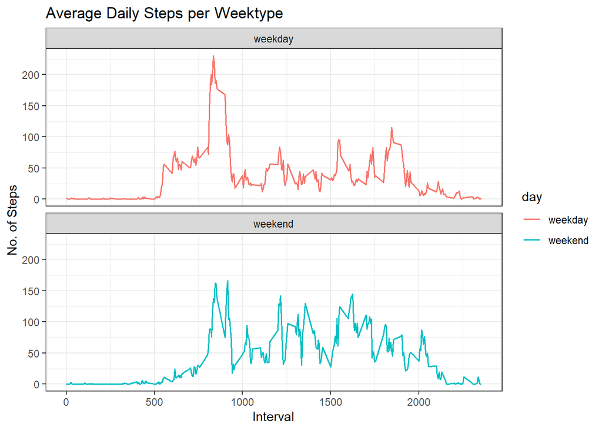

```r
ggplot(interval.plotData, aes(x=interval,y=steps, color=day)) + geom_line(size = 0.6) + theme_bw() +
               labs(title = "Average Daily Steps per Weektype", x = "Interval", y = "No. of Steps") +
               facet_wrap(.~day, ncol=1, nrow=2)
```